# Software for Data Analysis - Project 2

# 4 Methods

## 4.1 Linear Regression and Model Selection

The models have been developed using backward, forwards and AIC steps wise selection to be able to choose the best model. The result of each model can be seen in separate table below:

### 4.1.1 Backward Selection

We start with a full model, including each independent variable in the mode

```r
fitness.backward <- step(lm(Oxygen~Age+Weight+RunTime+RestPulse+RunPulse+MaxPulse,
                            data = fitness),
                         direction = "backward")
```

```
## Start:  AIC=58.16
## Oxygen ~ Age + Weight + RunTime + RestPulse + RunPulse + MaxPulse
##
##             Df Sum of Sq    RSS    AIC
## - RestPulse  1     0.571 129.41 56.299
## <none>                   128.84 58.162
## - Weight     1     9.911 138.75 58.459
## - MaxPulse   1    26.491 155.33 61.958
## - Age        1    27.746 156.58 62.208
## - RunPulse   1    51.058 179.90 66.510
## - RunTime    1   250.822 379.66 89.664
##
## Step:  AIC=56.3
## Oxygen ~ Age + Weight + RunTime + RunPulse + MaxPulse
##
##            Df Sum of Sq    RSS    AIC
## <none>                  129.41 56.299
## - Weight    1      9.52 138.93 56.499
## - MaxPulse  1     26.83 156.23 60.139
## - Age       1     27.37 156.78 60.247
## - RunPulse  1     52.60 182.00 64.871
## - RunTime   1    320.36 449.77 92.917
```

Below a summary of backward selection can be seen:

```r
summary(fitness.backward)
```

```
##
## Call:
## lm(formula = Oxygen ~ Age + Weight + RunTime + RunPulse + MaxPulse,
##     data = fitness)
##
## Residuals:
##     Min      1Q  Median      3Q     Max
## -5.4724 -0.8476  0.0094  0.9976  5.3807
##
## Coefficients:
##              Estimate Std. Error t value Pr(>|t|)
## (Intercept) 102.20428   11.97929   8.532 7.13e-09 ***
## Age          -0.21962    0.09550  -2.300  0.03010 *
## Weight       -0.07230    0.05331  -1.356  0.18714
## RunTime      -2.68252    0.34099  -7.867 3.19e-08 ***
## RunPulse     -0.37340    0.11714  -3.188  0.00383 **
## MaxPulse      0.30491    0.13394   2.277  0.03164 *
## ---
## Signif. codes:  0 '***' 0.001 '**' 0.01 '*' 0.05 '.' 0.1 ' ' 1
##
## Residual standard error: 2.275 on 25 degrees of freedom
## Multiple R-squared:  0.848,  Adjusted R-squared:  0.8176
## F-statistic:  27.9 on 5 and 25 DF,  p-value: 1.811e-09
```

### 4.1.2 Backward Selection Using drop1() and update()

After using step function for backward selection we compare the previous methos method with selection using **drop1()** and **update()** function.

```r
fitness.backward2 <- lm(Oxygen~Age+Weight+RunTime+RestPulse+RunPulse+MaxPulse, data = fitness)
drop1(fitness.backward2, test = "F")
```

```
## Single term deletions
##
## Model:
## Oxygen ~ Age + Weight + RunTime + RestPulse + RunPulse + MaxPulse
##           Df Sum of Sq    RSS    AIC F value    Pr(>F)
## <none>                 128.84 58.162
## Age        1    27.746 156.58 62.208  5.1685  0.032235 *
## Weight     1     9.911 138.75 58.459  1.8461  0.186866
## RunTime    1   250.822 379.66 89.664 46.7233 4.538e-07 ***
## RestPulse  1     0.571 129.41 56.299  0.1063  0.747250
## RunPulse   1    51.058 179.90 66.510  9.5111  0.005079 **
## MaxPulse   1    26.491 155.33 61.958  4.9348  0.036007 *
## ---
## Signif. codes:  0 '***' 0.001 '**' 0.01 '*' 0.05 '.' 0.1 ' ' 1
```

```r
fitness.backward2 <- update(fitness.backward2, .~.-RestPulse)
drop1(fitness.backward2, test = "F")
```

```
## Single term deletions
##
## Model:
## Oxygen ~ Age + Weight + RunTime + RunPulse + MaxPulse
##          Df Sum of Sq    RSS    AIC F value    Pr(>F)
## <none>                129.41 56.299
## Age       1     27.37 156.78 60.247  5.2884   0.03010 *
## Weight    1      9.52 138.93 56.499  1.8394   0.18714
## RunTime   1    320.36 449.77 92.917 61.8892 3.186e-08 ***
## RunPulse  1     52.60 182.00 64.871 10.1609   0.00383 **
## MaxPulse  1     26.83 156.23 60.139  5.1825   0.03164 *
## ---
## Signif. codes:  0 '***' 0.001 '**' 0.01 '*' 0.05 '.' 0.1 ' ' 1
```

```r
fitness.backward2 <- update(fitness.backward2, .~.-Weight)
drop1(fitness.backward2, test = "F")
```

```
## Single term deletions
##
## Model:
## Oxygen ~ Age + RunTime + RunPulse + MaxPulse
##          Df Sum of Sq    RSS    AIC F value    Pr(>F)
## <none>                138.93 56.499
## Age       1     22.84 161.77 59.218  4.2748  0.048768 *
## RunTime   1    352.94 491.87 93.691 66.0500 1.315e-08 ***
## RunPulse  1     46.90 185.83 63.516  8.7772  0.006443 **
## MaxPulse  1     21.90 160.83 59.037  4.0986  0.053305 .
## ---
## Signif. codes:  0 '***' 0.001 '**' 0.01 '*' 0.05 '.' 0.1 ' ' 1
```

```r
fitness.backward2 <- update(fitness.backward2, .~.-MaxPulse)
summary(fitness.backward2)
```

```
##
## Call:
## lm(formula = Oxygen ~ Age + RunTime + RunPulse, data = fitness)
##
## Residuals:
##     Min      1Q  Median      3Q     Max
## -4.8752 -1.2493  0.2606  1.0324  4.8994
##
## Coefficients:
##              Estimate Std. Error t value Pr(>|t|)
## (Intercept) 111.71806   10.23509  10.915 2.10e-11 ***
## Age          -0.25640    0.09623  -2.664   0.0129 *
## RunTime      -2.82538    0.35828  -7.886 1.77e-08 ***
## RunPulse     -0.13091    0.05059  -2.588   0.0154 *
## ---
## Signif. codes:  0 '***' 0.001 '**' 0.01 '*' 0.05 '.' 0.1 ' ' 1
##
## Residual standard error: 2.441 on 27 degrees of freedom
## Multiple R-squared:  0.8111, Adjusted R-squared:  0.7901
## F-statistic: 38.64 on 3 and 27 DF,  p-value: 6.557e-10
```

### 4.1.3 Forward Selection

In this method we start with intercept only model and then perform series of independent test to determine which of the predictor variables significantly improve the goodness of fit.

```r
fitness.forward <- step(lm(Oxygen~1, data = fitness),
                        direction = "forward",
                        scope =~ Age+Weight+RunTime+RestPulse+RunPulse+MaxPulse)
```

```
## Start:  AIC=104.7
## Oxygen ~ 1
##
##             Df Sum of Sq    RSS     AIC
## + RunTime    1    632.90 218.48  64.534
## + RestPulse  1    135.78 715.60 101.313
## + RunPulse   1    134.84 716.54 101.354
## + Age        1     78.99 772.39 103.681
## <none>                   851.38 104.699
## + MaxPulse   1     47.72 803.67 104.911
## + Weight     1     22.55 828.83 105.867
##
## Step:  AIC=64.53
## Oxygen ~ RunTime
##
##             Df Sum of Sq    RSS    AIC
## + Age        1   17.7656 200.72 63.905
## + RunPulse   1   15.3621 203.12 64.274
## <none>                   218.48 64.534
## + MaxPulse   1    1.5674 216.91 66.311
## + Weight     1    1.3236 217.16 66.346
## + RestPulse  1    0.1301 218.35 66.516
##
## Step:  AIC=63.9
## Oxygen ~ RunTime + Age
##
##             Df Sum of Sq    RSS    AIC
## + RunPulse   1    39.885 160.83 59.037
## + MaxPulse   1    14.885 185.83 63.516
## <none>                   200.72 63.905
## + Weight     1     5.605 195.11 65.027
## + RestPulse  1     2.641 198.07 65.494
##
## Step:  AIC=59.04
## Oxygen ~ RunTime + Age + RunPulse
##
##             Df Sum of Sq    RSS    AIC
## + MaxPulse   1   21.9007 138.93 56.499
## <none>                   160.83 59.037
## + Weight     1    4.5958 156.24 60.139
## + RestPulse  1    0.4901 160.34 60.943
##
## Step:  AIC=56.5
## Oxygen ~ RunTime + Age + RunPulse + MaxPulse
##
##             Df Sum of Sq    RSS    AIC
## + Weight     1    9.5216 129.41 56.299
## <none>                   138.93 56.499
## + RestPulse  1    0.1815 138.75 58.459
##
## Step:  AIC=56.3
## Oxygen ~ RunTime + Age + RunPulse + MaxPulse + Weight
##
##             Df Sum of Sq    RSS    AIC
## <none>                   129.41 56.299
## + RestPulse  1   0.57051 128.84 58.162
```

### 4.1.4 Forward Selection Using Add1() and update()

In this section we decided to compare the forward selection method using **step()** function and forward selection using **add1()** and **update()** function.

```r
fitness.forward2 <- lm(Oxygen~1, data = fitness)
```

Here we selected our intercept and created the initial model.

```r
add1(fitness.forward2, scope = .~.+Age+Weight+RunTime+RestPulse+RunPulse+MaxPulse, test = "F")
```

```
## Single term additions
##
## Model:
## Oxygen ~ 1
##           Df Sum of Sq    RSS     AIC F value    Pr(>F)
## <none>                 851.38 104.699
## Age        1     78.99 772.39 103.681  2.9657   0.09570 .
## Weight     1     22.55 828.83 105.867  0.7891   0.38169
## RunTime    1    632.90 218.48  64.534 84.0076 4.585e-10 ***
## RestPulse  1    135.78 715.60 101.313  5.5027   0.02604 *
## RunPulse   1    134.84 716.54 101.354  5.4575   0.02660 *
## MaxPulse   1     47.72 803.67 104.911  1.7218   0.19975
## ---
## Signif. codes:  0 '***' 0.001 '**' 0.01 '*' 0.05 '.' 0.1 ' ' 1
```

Using the **add1()** we examine which predictor has the most significant p-value. As can be seen in the result the RunTime has the most significant value.

```r
fitness.forward2 <- update(fitness.forward2, formula. = .~.+RunTime)
```

Therfore, using the **update()** function we update our model and add the RunTime plus to it.

```r
add1(fitness.forward2, scope =.~.+Age+Weight+RunTime+RestPulse+RunPulse+MaxPulse, test = "F")
```

```
## Single term additions
##
## Model:
## Oxygen ~ RunTime
##           Df Sum of Sq    RSS    AIC F value Pr(>F)
## <none>                 218.48 64.534
## Age        1   17.7656 200.72 63.905  2.4783 0.1267
## Weight     1    1.3236 217.16 66.346  0.1707 0.6827
## RestPulse  1    0.1301 218.35 66.516  0.0167 0.8981
## RunPulse   1   15.3621 203.12 64.274  2.1177 0.1567
## MaxPulse   1    1.5674 216.91 66.311  0.2023 0.6563
```

Running add again surprisingly we can see none of the predictors are showing any significant value and forward method ends here. However, in order to measure quality of our model we can run **AIC()** to check whether there is any improvment compare to the other models.

```r
AIC(fitness.forward2)
```

```
## [1] 154.5083
```

AS it can be seen it is significan’t higher than the other models. So, for sure not the best candidate for the best model.

Below we can see the summary of our model.

```r
summary(fitness.forward2)
```

```
##
## Call:
## lm(formula = Oxygen ~ RunTime, data = fitness)
##
## Residuals:
##     Min      1Q  Median      3Q     Max
## -5.3352 -1.8424 -0.0569  1.5342  6.2033
##
## Coefficients:
##             Estimate Std. Error t value Pr(>|t|)
## (Intercept)  82.4218     3.8553  21.379  < 2e-16 ***
## RunTime      -3.3106     0.3612  -9.166 4.59e-10 ***
## ---
## Signif. codes:  0 '***' 0.001 '**' 0.01 '*' 0.05 '.' 0.1 ' ' 1
##
## Residual standard error: 2.745 on 29 degrees of freedom
## Multiple R-squared:  0.7434, Adjusted R-squared:  0.7345
## F-statistic: 84.01 on 1 and 29 DF,  p-value: 4.585e-10
```

### 4.1.5 Stepwise AIC Selection

Here every block of output shows the current model fit, the AIC value and a table showing the possible moves. The AIC value that result from every move is listedand every move os ranked from samlles to largest AIC value. The model shows formula as **Oxygen ~ Age + Weight + RunTime + RunPulse + MaxPulse**

```r
fitness.stepwise <- step(lm(Oxygen~Age+Weight+RunTime+RestPulse+RunPulse+MaxPulse,
                            data = fitness),
                         direction = "both")
```

```
## Start:  AIC=58.16
## Oxygen ~ Age + Weight + RunTime + RestPulse + RunPulse + MaxPulse
##
##             Df Sum of Sq    RSS    AIC
## - RestPulse  1     0.571 129.41 56.299
## <none>                   128.84 58.162
## - Weight     1     9.911 138.75 58.459
## - MaxPulse   1    26.491 155.33 61.958
## - Age        1    27.746 156.58 62.208
## - RunPulse   1    51.058 179.90 66.510
## - RunTime    1   250.822 379.66 89.664
##
## Step:  AIC=56.3
## Oxygen ~ Age + Weight + RunTime + RunPulse + MaxPulse
##
##             Df Sum of Sq    RSS    AIC
## <none>                   129.41 56.299
## - Weight     1      9.52 138.93 56.499
## + RestPulse  1      0.57 128.84 58.162
## - MaxPulse   1     26.83 156.23 60.139
## - Age        1     27.37 156.78 60.247
## - RunPulse   1     52.60 182.00 64.871
## - RunTime    1    320.36 449.77 92.917
```

```r
summary(fitness.stepwise)
```

```
##
## Call:
## lm(formula = Oxygen ~ Age + Weight + RunTime + RunPulse + MaxPulse,
##     data = fitness)
##
## Residuals:
##     Min      1Q  Median      3Q     Max
## -5.4724 -0.8476  0.0094  0.9976  5.3807
##
## Coefficients:
##              Estimate Std. Error t value Pr(>|t|)
## (Intercept) 102.20428   11.97929   8.532 7.13e-09 ***
## Age          -0.21962    0.09550  -2.300  0.03010 *
## Weight       -0.07230    0.05331  -1.356  0.18714
## RunTime      -2.68252    0.34099  -7.867 3.19e-08 ***
## RunPulse     -0.37340    0.11714  -3.188  0.00383 **
## MaxPulse      0.30491    0.13394   2.277  0.03164 *
## ---
## Signif. codes:  0 '***' 0.001 '**' 0.01 '*' 0.05 '.' 0.1 ' ' 1
##
## Residual standard error: 2.275 on 25 degrees of freedom
## Multiple R-squared:  0.848,  Adjusted R-squared:  0.8176
## F-statistic:  27.9 on 5 and 25 DF,  p-value: 1.811e-09
```

### 4.1.6 Stepwise AIC Selection using Interactions

In this section we are compring pur previous model with stepwise AIC selection and interaction between our each predictor.

```r
fitness.stepwise2 <- step(lm(Oxygen~1, data = fitness),
                          scope =~ Age*Weight*RunTime*RestPulse*RunPulse*MaxPulse,
                          direction = "both")
```

```
## Start:  AIC=104.7
## Oxygen ~ 1
##
##             Df Sum of Sq    RSS     AIC
## + RunTime    1    632.90 218.48  64.534
## + RestPulse  1    135.78 715.60 101.313
## + RunPulse   1    134.84 716.54 101.354
## + Age        1     78.99 772.39 103.681
## <none>                   851.38 104.699
## + MaxPulse   1     47.72 803.67 104.911
## + Weight     1     22.55 828.83 105.867
##
## Step:  AIC=64.53
## Oxygen ~ RunTime
##
##             Df Sum of Sq    RSS     AIC
## + Age        1     17.77 200.72  63.905
## + RunPulse   1     15.36 203.12  64.274
## <none>                   218.48  64.534
## + MaxPulse   1      1.57 216.91  66.311
## + Weight     1      1.32 217.16  66.346
## + RestPulse  1      0.13 218.35  66.516
## - RunTime    1    632.90 851.38 104.699
##
## Step:  AIC=63.9
## Oxygen ~ RunTime + Age
##
##               Df Sum of Sq    RSS     AIC
## + RunPulse     1     39.89 160.83  59.037
## + MaxPulse     1     14.88 185.83  63.516
## <none>                     200.72  63.905
## - Age          1     17.77 218.48  64.534
## + Weight       1      5.61 195.11  65.027
## + Age:RunTime  1      3.08 197.64  65.426
## + RestPulse    1      2.64 198.07  65.494
## - RunTime      1    571.68 772.39 103.681
##
## Step:  AIC=59.04
## Oxygen ~ RunTime + Age + RunPulse
##
```

[output cut: 36 more lines]

```
## + Age:Weight         1      6.94 122.47 56.590
## + Age:RunPulse       1      4.93 124.48 57.095
## + RunPulse:MaxPulse  1      4.13 125.28 57.294
## + Weight:RunTime     1      2.53 126.88 57.687
## + Age:RunTime        1      2.22 127.19 57.762
## + Age:MaxPulse       1      0.94 128.47 58.072
## + RestPulse          1      0.57 128.84 58.162
## + RunTime:MaxPulse   1      0.08 129.33 58.280
## + RunTime:RunPulse   1      0.05 129.35 58.286
## + Weight:MaxPulse    1      0.04 129.37 58.289
## + Weight:RunPulse    1      0.00 129.40 58.298
## - MaxPulse           1     26.83 156.23 60.139
## - Age                1     27.37 156.78 60.247
## - RunPulse           1     52.60 182.00 64.871
## - RunTime            1    320.36 449.77 92.917
```

```r
summary(fitness.stepwise2)
```

```
##
## Call:
## lm(formula = Oxygen ~ RunTime + Age + RunPulse + MaxPulse + Weight,
##     data = fitness)
##
## Residuals:
##     Min      1Q  Median      3Q     Max
## -5.4724 -0.8476  0.0094  0.9976  5.3807
##
## Coefficients:
##              Estimate Std. Error t value Pr(>|t|)
## (Intercept) 102.20428   11.97929   8.532 7.13e-09 ***
## RunTime      -2.68252    0.34099  -7.867 3.19e-08 ***
## Age          -0.21962    0.09550  -2.300  0.03010 *
## RunPulse     -0.37340    0.11714  -3.188  0.00383 **
## MaxPulse      0.30491    0.13394   2.277  0.03164 *
## Weight       -0.07230    0.05331  -1.356  0.18714
## ---
## Signif. codes:  0 '***' 0.001 '**' 0.01 '*' 0.05 '.' 0.1 ' ' 1
##
## Residual standard error: 2.275 on 25 degrees of freedom
## Multiple R-squared:  0.848,  Adjusted R-squared:  0.8176
## F-statistic:  27.9 on 5 and 25 DF,  p-value: 1.811e-09
```

As a result of fitting this model we can see that none of the interaction have significan’t influence on this model as none of them are included in the final iteration

## 4.2 Summary of Model Selection

Selection of model has been done using each models summary independently however, below table shows a summary of all the fitted models:

```r
mtable123 <- mtable('Backward' = fitness.backward,
                    'Backward Manual' = fitness.backward2,
                    'Forward' = fitness.forward,
                    'Forward Manual' = fitness.forward2,
                    'Stepwise AIC' = fitness.forward,
                    'Stepwise AIC, Interation' = fitness.stepwise,
                    summary.stats = c('R-squared','F','p','N'))
mtable123
```

```
##
## Calls:
## Backward: lm(formula = Oxygen ~ Age + Weight + RunTime + RunPulse + MaxPulse,
##     data = fitness)
## Backward Manual: lm(formula = Oxygen ~ Age + RunTime + RunPulse, data = fitness)
## Forward: lm(formula = Oxygen ~ RunTime + Age + RunPulse + MaxPulse + Weight,
##     data = fitness)
## Forward Manual: lm(formula = Oxygen ~ RunTime, data = fitness)
## Stepwise AIC: lm(formula = Oxygen ~ RunTime + Age + RunPulse + MaxPulse + Weight,
##     data = fitness)
## Stepwise AIC, Interation: lm(formula = Oxygen ~ Age + Weight + RunTime + RunPulse + MaxPulse,
##     data = fitness)
##
## ================================================================================================================
##                 Backward   Backward Manual   Forward    Forward Manual  Stepwise AIC  Stepwise AIC, Interation
## ----------------------------------------------------------------------------------------------------------------
##   (Intercept)  102.204***    111.718***     102.204***    82.422***      102.204***          102.204***
##                (11.979)      (10.235)       (11.979)      (3.855)        (11.979)            (11.979)
##   Age           -0.220*       -0.256*        -0.220*                      -0.220*             -0.220*
##                 (0.096)       (0.096)        (0.096)                      (0.096)             (0.096)
##   Weight        -0.072                       -0.072                       -0.072              -0.072
##                 (0.053)                      (0.053)                      (0.053)             (0.053)
##   RunTime       -2.683***     -2.825***      -2.683***    -3.311***       -2.683***           -2.683***
##                 (0.341)       (0.358)        (0.341)      (0.361)         (0.341)             (0.341)
##   RunPulse      -0.373**      -0.131*        -0.373**                     -0.373**            -0.373**
##                 (0.117)       (0.051)        (0.117)                      (0.117)             (0.117)
##   MaxPulse       0.305*                       0.305*                       0.305*              0.305*
##                 (0.134)                      (0.134)                      (0.134)             (0.134)
## ----------------------------------------------------------------------------------------------------------------
##   R-squared      0.848         0.811          0.848        0.743           0.848               0.848
##   F             27.895        38.643         27.895       84.008          27.895              27.895
##   p              0.000         0.000          0.000        0.000           0.000               0.000
##   N             31            31             31           31              31                  31
## ================================================================================================================
```

### 4.2.1 Multicollinearity

As we discussed in earlier stages, the R function **vif()** from car package can be used to detect multicollinearity in a regression model:

```r
vif(fitness.stepwise)
```

```
##      Age   Weight  RunTime RunPulse MaxPulse
## 1.435634 1.142505 1.297127 8.358594 8.731225
```

Any variable with a high VIF value (above 5 or 10) should be removed from the model. This leads to a simpler model without compromising the model accuracy, which is good. As it was expected we can see the correlation between RunPulse and MaxPulse are leading to multicollinearity. So, we’ll update our model by removing the the predictor variables with high VIF value and keep RunPluse as it provided the highest AIC during the model fitting.

```r
fitness.stepwise <- update(fitness.stepwise, .~.-MaxPulse)
```

Checking collinearity again:

```r
vif(fitness.stepwise)
```

```
##      Age   Weight  RunTime RunPulse
## 1.337660 1.101545 1.279750 1.356487
```

We don’t see any issue with colliniearity. Hence our final model is **Oxygen ~ Age + Weight + RunTime + RunPulse**

### 4.2.2 Normality

In a linear regression the residuals or errors in observed data is assumed to be normally distributed. A Shapiro-Wilk hypothesis test suggests normal residuals per below results:

```r
shapiro.test(rstandard(fitness.stepwise))
```

```
##
##  Shapiro-Wilk normality test
##
## data:  rstandard(fitness.stepwise)
## W = 0.96344, p-value = 0.3587
```

Cross checking the shapiro test with our upcoming QQ norm we can see that the normality is available in our model. As the null hypothesis has not been rejected with p-value of 0.35. The null hypothesis for Shapiro test is that the data are normally distributed. Being able to assume normality of the error term supports the methodology used to produce reliable estimates of the regression coefficients.

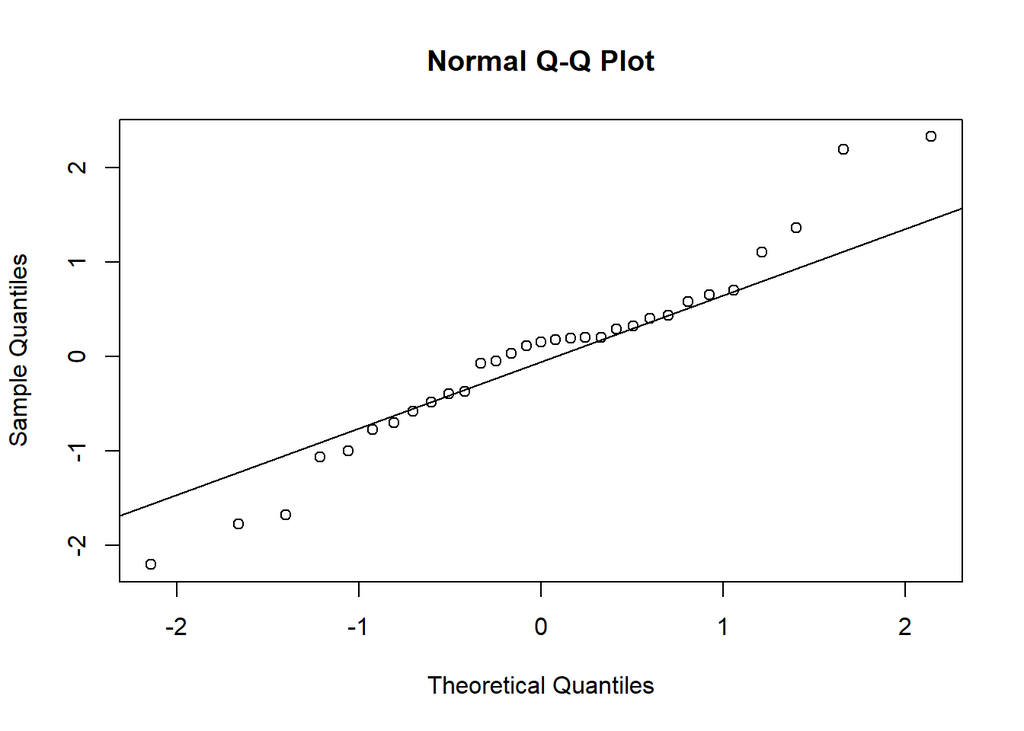

```r
qqnorm(rstandard(fitness.stepwise))
qqline(rstandard(fitness.stepwise))
```

### 4.2.3 Non-constant Variance Score Test

In terms of variance of our fitted model using stepwise AIC selection, running non-constant variance score test, we used ncvTest which the results are as below:

```r
ncvTest(fitness.stepwise)
```

```
## Non-constant Variance Score Test
## Variance formula: ~ fitted.values
## Chisquare = 1.891741, Df = 1, p = 0.16901
```

The p-value of 0.17 shows we can’t reject the null hypothesis which indicates the variance of the residuals is constant and infer that heteroscedasticity is not present.